# Lineaire Regressie

Nastazio Boon (500804722), Zhiran Dai (500804341), Jitse Ruurd Nauta (500803030), Yúri Grings (500801949)

2-12-2020

Packages installeren

```r
library(ggplot2) #Visualisaties
library(ggpubr) #Visualisaties
library(tidyverse) #Data bewerken
library(Hmisc) #Data bewerken
```

Voor deze demo maken we gebruik van 2 datasets die gaan over de verkoop van tweedehands Fiat 500’s in Italië. Eerst zorgen we dat allebei de datsets dezelfde kolommen hebben door de ‘transmission’ kolom bij set 1 weg te halen. Vervolgens voegen we de datasets samen en halen we de irrelevante waarneming van het model ‘star’ weg om een beter model te kunnen maken.

```r
Fiat <- read.csv("Fiat500.csv")
Fiat2 <- read.csv("Fiat500_2.csv")
Fiat$transmission <- NULL
Fiat <- Fiat %>%
    bind_rows(Fiat2)
Fiat$model <- capitalize(Fiat$model)
Fiat <- Fiat %>%
    filter(model != "Star")
```

Voordat je een lineair regressie model opstelt, is het belangrijk om te bepalen wat je wilt voorspellen en aan de hand van wat. Voor deze dataset zou je vooraf kunnen bedenken dat de prijs van een auto onder andere bepaald wordt door het aantal gereden kilometers en de ‘leeftijd’. Om te kijken of er ook echt een lineair verband is tussen deze factoren kunnen we een scatterplot van beide maken. Voor zowel de kilometerstand als de leeftijd is een lineair verband te zien t.o.v. de prijs dus deze variabelen kunnen gebruikt worden voor een lineair regressie model.

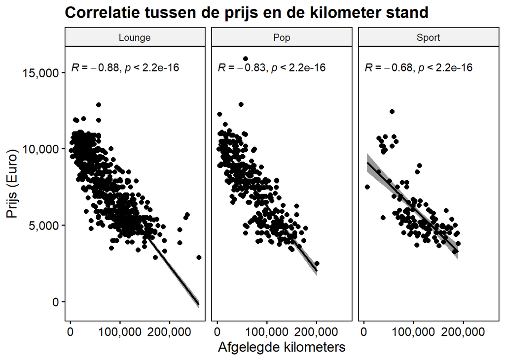

```r
ggscatter(Fiat, x = "km", y = "price",
                      add = "reg.line", conf.int = TRUE,
                      cor.coef = TRUE, cor.method = "pearson", title = "Correlatie tussen de prijs en de kilometer stand",
                      xlab = "Afgelegde kilometers", ylab = "Prijs (Euro)",facet.by = "model") +
                theme(plot.title = element_text(size = 16, face = "bold"),
                      axis.title = element_text(size=14)) +
                scale_x_continuous(labels = scales::comma) + scale_y_continuous(labels = scales::comma)
```

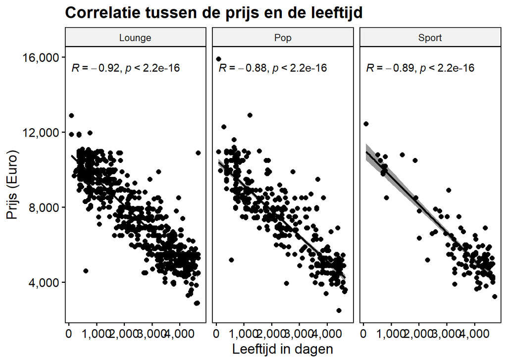

```r
ggscatter(Fiat, x = "age_in_days", y = "price",
                      add = "reg.line", conf.int = TRUE,
                      cor.coef = TRUE, cor.method = "pearson", title = "Correlatie tussen de prijs en de leeftijd",
                      xlab = "Leeftijd in dagen", ylab = "Prijs (Euro)",facet.by = "model") +
                theme(plot.title = element_text(size = 16, face = "bold"),
                      axis.title = element_text(size = 14)) +
                scale_x_continuous(labels = scales::comma) + scale_y_continuous(labels = scales::comma)
```

Met dit model willen we dus de prijs (price) van een Fiat 500 bepalen aan de hand van 2 variabelen; kilometerstand (km) en leeftijd van de auto (age_in_days). Omdat we 2 verklarende variabelen gebruiken om een afhankelijke waarde te voorspellen, gaat het hier om meervoudige regressie. Omdat we het model zowel willen trainen als testen, moeten we de dataset opsplitsen in een trainset en testset.

```r
set.seed(123)  #Zodat het reproduceerbaar is
trainingRowIndex <- sample(1:nrow(Fiat), 0.8*nrow(Fiat))  #Trainset creëren
trainingData <- Fiat[trainingRowIndex, ]  #Trainset
testData  <- Fiat[-trainingRowIndex, ]   #Testset
```

Nu we onze train en test data hebben kunnen we het model gaan opstellen. Hier gebruiken we dus eerst de trainset voor.

```r
lineair_model <- lm(formula = price ~ km + age_in_days, data = trainingData)
```

Nu het model is opgesteld kunnen we de resultaten eruit halen en visualiseren om zo te kijken of het model goed werkt op deze dataset. Allereerst kijken we naar de ‘model summary’ die laat zien of de verklarende variabelen significant zijn of niet en hoe hoog de R-squared waarde is. In de summary kan de significantie uit de Pr(>|t|) kolom gehaald worden van het kopje ‘Coefficients’. Hier is te zien dat beide variabelen, km en age_in_days, significant zijn want < 0.05 (Zichtbaar in de regel ‘Signif. codes’). Zoals gezegd gaat het in dit voorbeeld om meervoudige regressie dus moeten we naar de Adjusted R-squared waarde kijken. Deze waarde valt altijd tussen de 0 en 1 en hoe hoger deze is, hoe beter het model is. In dit voorbeeld is de Adjusted R-squared 0.8672 wat dus heel goed is. Dit geeft aan hoeveel variantie van de verklaarde variabele (price) wordt verklaard door de verklarende variabelen (km en age_in_days).

```r
summary(lineair_model)
```

```
##
## Call:
## lm(formula = price ~ km + age_in_days, data = trainingData)
##
## Residuals:
##     Min      1Q  Median      3Q     Max
## -3921.3  -535.1   -53.0   517.5  5300.5
##
## Coefficients:
##               Estimate Std. Error t value Pr(>|t|)
## (Intercept)  1.097e+04  3.646e+01  300.89   <2e-16 ***
## km          -1.640e-02  8.493e-04  -19.31   <2e-16 ***
## age_in_days -9.533e-01  2.643e-02  -36.07   <2e-16 ***
## ---
## Signif. codes:  0 '***' 0.001 '**' 0.01 '*' 0.05 '.' 0.1 ' ' 1
##
## Residual standard error: 816.5 on 1530 degrees of freedom
## Multiple R-squared:  0.8674, Adjusted R-squared:  0.8672
## F-statistic:  5003 on 2 and 1530 DF,  p-value: < 2.2e-16
```

Vervolgens kunnen we kijken naar een Q-Q plot van de residuen. Dit geeft aan of de residuen normaal verdeeld zijn. Bij een lineaire regressie is dat namelijk de bedoeling. De residuen zijn normaal verdeeld als je een rechte lijn door de punten van de Q-Q plot kunt trekken. In dit voorbeeld zijn er slechts een paar punten die niet op deze lijn vallen dus over het algemeen kan gesteld worden dat de residuen in dit model normaal verdeeld zijn.

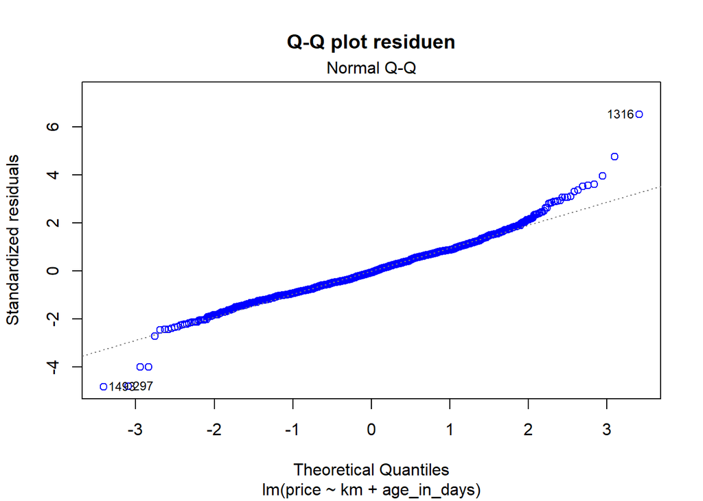

```r
plot(lineair_model, which=2, col=c("blue"), main = 'Q-Q plot residuen')
```

Een andere voorwaarde voor lineaire regressie is de homoscedasticiteit. Dit betekent dat de variantie van de residuen gelijk is voor alle waarden van de verklarende variabelen. Dit kunnen we checken in de volgende visualisatie. De residuen boven de lijn (het model) moeten ongeveer dezelfde spreiding hebben als de residuen onder de lijn. Dit lijkt op enkele punten na het geval te zijn.

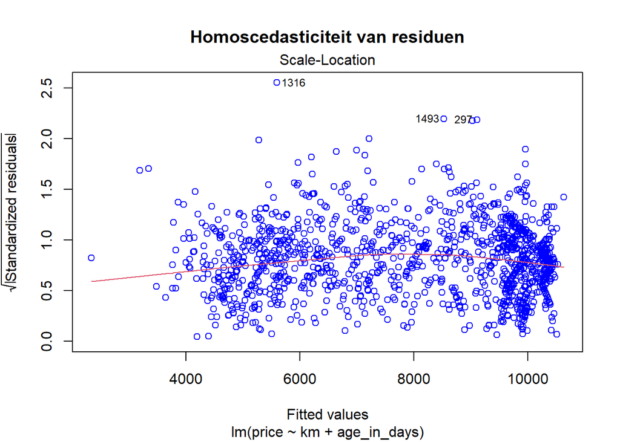

```r
plot(lineair_model, which=3, col=c("blue"), main = 'Homoscedasticiteit van residuen')
```

Nu we naar verschillende resultaten van het model hebben gekeken, kan geconcludeerd worden dat lineaire regressie goed toe te passen is op deze dataset en de gekozen variabelen. Dit kunnen we nu gaan testen op de testset. Vervolgens zijn de verschillen tussen de daadwerkelijke prijs en de voorspelde prijs zichtbaar in de laatste 2 kolommen van de dataset.

```r
test_lineair_model <- predict(lineair_model, testData)
gecombineerd <- cbind(testData, test_lineair_model)
head(gecombineerd[,c(8,9)],n = 25)
```

```
##     price test_lineair_model
## 3    4500           4875.581
## 7    4950           5344.416
## 15   6499           5481.976
## 21   7000           7128.473
## 22   7100           8922.823
## 25   7300           7620.761
## 36   8299          10108.548
## 43   9300           9546.388
## 47   9490          10317.913
## 50   9499          10290.442
## 53   9590          10339.666
## 57   9690          10380.844
## 62   9850           9904.260
## 66   9900          10077.972
## 68   9900          10508.946
## 74   9970          10328.653
## 82  10900          10177.190
## 85  11090          10184.810
## 97  15900           9953.367
## 107  3700           5250.397
## 109  3800           3647.695
## 110  3900           4877.457
## 111  3900           5094.068
## 116  3900           5340.020
## 123  4000           4322.629
```